# 36-315 Lab 02

SOLUTIONS

Due Saturday, September 11, 2021 (12pm)

## Lab 02: Inference for 1D Categorical Data, and Looking at 2D Categorical Data

# Problem 1: Chi-Square Tests and Confidence Intervals (45pts)

As we’ve discussed in class, bar charts are usually easier to read than spine charts, pie charts, and rose diagrams. There are several ways we can add even more useful information to bar charts, as we’ll explore throughout this lab.

In this assignment, we’ll be using the data of IMDb rated films, TV Series, etc. as rated by Professor Matey Neykov in the statistics department (thank you Matey for providing the data!)

The data is available on Github and can be loaded with the code below:

```r
library(tidyverse)

# reads IMDb rated movies TV Series, etc.
mateys_imdb <- read.csv("https://raw.githubusercontent.com/zjbranson/315Fall2021/master/imdb_ratings.csv")

# filters only Featured Films
mateys_movies <- mateys_imdb %>% filter(Title.type == "Feature Film")
```

For a description of the variables in the dataset, please read [here](https://raw.githubusercontent.com/zjbranson/315Fall2021/master/imdb_ratings_variables.txt).

1. (5pts) First, let us find the most frequent directors which appear in this dataset. Code is provided below.

```r
mateys_movies %>% group_by(Directors) %>% summarize(count = n()) %>%
  filter(count == max(count))
```

```
## # A tibble: 3 x 2
##   Directors         count
##   <chr>             <int>
## 1 Christopher Nolan     9
## 2 David Fincher         9
## 3 Martin Scorsese       9
```

In the above code, `%>%` is called the “pipe” operator. `x %>% f(y)` means the same thing as `f(x, y)`. The pipe operator is useful in making code easily readable and understandable. **Note that you need to load the `tidyverse` library before you can use the pipe operator.**

Given this, what is the above code doing, and in particular what is the purpose of the `filter(count == max(count))`?

*`group_by(Directors)` creates groups of films with the same director. `summarize(count = n())` counts the number of films for each director. `filter(count == max(count))` only displays the counts of films from directors with the maximum number of rated films. Since Matey has rated at most 9 films from the same director, this code displays the directors and number of film ratings (9) for directors for whom Matey has rated 9 films.*

2. (5pts) The following code adds some additional variables to the dataset.

```r
mateys_movies <- mutate(mateys_movies,
                    vote_date = as.Date(mateys_movies$created,
                                format = "%a %b %d %H:%M:%S %Y"),
                    day_of_week = weekdays(vote_date),
                    weekend = ifelse(day_of_week %in% c("Saturday", "Sunday"),
                                     "Weekend", "Workday"),
                    duration = cut(Runtime..mins., c(0, 90, 120, Inf),
                                        labels = c("Short", "Medium", "Long")),
                    ratings = cut(You.rated, c(0, 4, 7, Inf),
                                  labels = c("Low", "Med", "High")),
                    movie_period = cut(Year, c(0, 1980, 2000, 2018),
                              labels = c("Old", "Recent", "New"))
)
```

`vote_date` is the date Matey first rated the movie, `day_of_week` is the day of the week Matey rated the movie on, and `duration` is an ordinal categorical variable indicating how long the movie was.

In class we discussed **marginal distributions** for categorical variables; here we’ll examine the marginal distributions of the `movie_period` and `duration` variables. Do this by calculating the counts, proportions, and percentages of each variable. (Code is provided for `duration`; write the same code for `movie_period`.) Report your general observations in one sentence for each variable.

```r
#  Get counts, proportions, and percentages for duration
duration_marginal <- mateys_movies %>%
  group_by(duration) %>%
  summarize(count = n(),
            total = nrow(mateys_movies),
            proportion = round(count / total, 4),
            percentage = proportion * 100)
duration_marginal
```

```
## # A tibble: 3 x 5
##   duration count total proportion percentage
##   <fct>    <int> <int>      <dbl>      <dbl>
## 1 Short       53   737     0.0719       7.19
## 2 Medium     395   737     0.536       53.6
## 3 Long       289   737     0.392       39.2
```

```r
movie_period_marginal <- mateys_movies %>%
  group_by(movie_period) %>%
  summarize(count = n(),
            total = nrow(mateys_movies),
            proportion = round(count / total, 4),
            percentage = proportion * 100)
movie_period_marginal
```

```
## # A tibble: 3 x 5
##   movie_period count total proportion percentage
##   <fct>        <int> <int>      <dbl>      <dbl>
## 1 Old             26   737     0.0353       3.53
## 2 Recent         141   737     0.191       19.1
## 3 New            570   737     0.773       77.3
```

*Out of Matey’s rated movies, 7.19% of movies are short, 53.6% of movies are medium length, and 39.2% of movies are long. In terms of movie period, 3.53% of movies are old, 19.1% of movies are recent, and 77.3% of movies are new.*

Notice how, within the `summarize()` function, we can sequentially define a new variable and then refer to that new variable later on. For example, within `summarize()`, we first define a variable `total`, and then we refer to `total` when defining `proportion`.

3. (5pts) Marginal distributions are usually communicated with proportions or percentages; however, we’ve only discussed how to make bar plots in terms of *counts* instead of percentages. Now we’ll learn how to make bar plots in terms of percentages.

The goal of this question is to make a barplot of `duration` on the **percentage** scale instead of the count scale. In other words, we’d like to make a barplot where `duration` is on the x-axis and the `percentage` of each duration is on the y-axis. Note that `duration_marginal` has exactly this information - so, let’s use this dataset to make this barplot! Alter the template code below such that you’ve created a barplot with one bar for each `duration` whose height corresponds to the `percentage` of each duration. After you’ve made the plot, add appropriate titles, labels, and a non-default color.

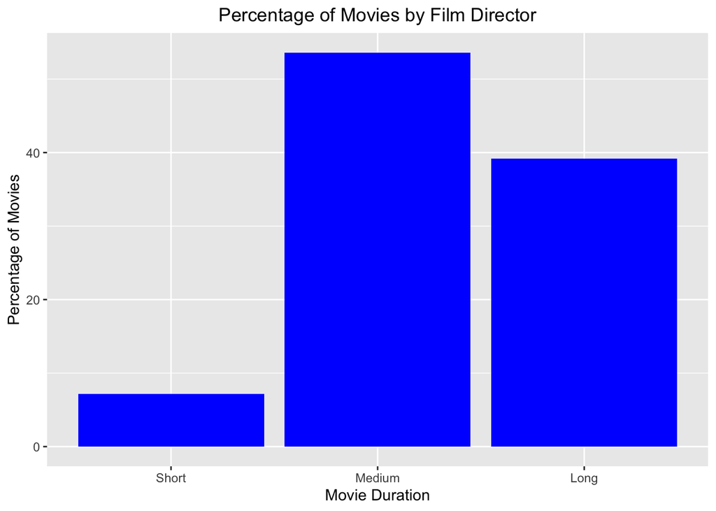

```r
#fill in the ?s below to make the desired plot
ggplot(data = duration_marginal, aes(x = duration, y = percentage)) +
  geom_bar(stat = "identity", fill = "blue") +
  labs(x = "Movie Duration", y = "Percentage of Movies",
       title = "Percentage of Movies by Film Director") +
  theme(plot.title = element_text(hjust = 0.5))
```

Note that, in this case, we needed to specify `stat = "identity"` within `geom_bar()`, because we want the height of the bars to correspond to whatever we put into `y`. This differs from the default `stat = "count"` within `geom_bar()`.

4. (5pts) Your friend thinks there are equal proportions of short, medium, and long movies in this dataset. Using your bar chart from Part C, do you think your friend is right? (This time, just use your common statistical sense. Given the sample size and the difference in the bars, do you think there is probably a significant difference?)

*No, I do not think there are equal proportions of short, medium, and long movies: Approximately 7% of the films are short, 54% of the films are medium duration, and 39% of the films are long. I am pretty certain they are not equal, because the number of medium duration films is more than 7 times the number of short films. That said, it can still be helpful to validate graphical results with statistical analyses, which we turn to next. Ineed, we can only formally conclude statistical significance from a statistical test, rather than just a graph.*

5. (10pts) Let’s test this statistically. Run a chi-square test to check your friend’s assertion: `chisq.test(duration_marginal$count)` will check to see if the proportions in each category are the same. After you run the test, answer the following questions:

```r
chisq.test(duration_marginal$count)
```

```
##
##  Chi-squared test for given probabilities
##
## data:  duration_marginal$count
## X-squared = 249.52, df = 2, p-value < 2.2e-16
```

- What is the p-value for this test?

*We see that the p-value is quite small; less than $2.2 \cdot 10^{-16}$.*

- What is your formal conclusion from this test?

*The null hypothesis is that the proportions of films in all categories are the same. We clearly reject the null hypothesis at $\alpha = 0.05$ (or any other reasonable significance level). This is strong evidence that the proportions of films in all categories are not the same.*

6. (5pts) It can be helpful to report p-values on graphs, so that it’s clear whether what we’re looking at is “statistically significant” in some sense. Now we will take the same plot you made in Part C, and report the p-value on top of the graph. For this part, follow these steps:
- First, copy-and-paste your code from Part C and place it here.
- Now add the following line of code: `+ geom_text(x = ?, y = ?, label = ?)`. Here, you should specify `x` and `y` as the x- and y-coordinates where you want your text, and `label` as the text itself in quotes. (Note: Because the x-axis is categorical, you can specify `x` as one of the categories or as a number.)
- In particular, specify `label` as your p-value from your chi-squared test in Part E (e.g., `label = "chi-squared test p-value = ?`), with ? appropriately specified. If you got an extremely small p-value, it’s fine if you just state “chi-squared test p-value approximately zero.” If you need to put your text on two lines, you can use `\n` within your `label` to create a line break.

For this part, you just need to have the exact same plot as Part C, but with the desired text added.

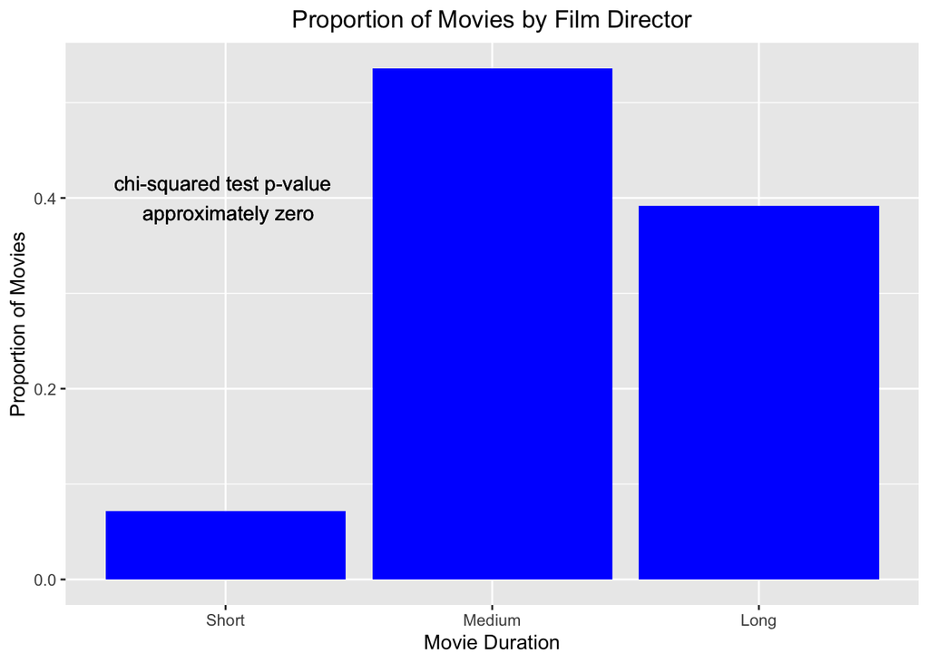

```r
#fill in the ?s below to make the desired plot
ggplot(data = duration_marginal, aes(x = duration, y = proportion)) +
  geom_bar(stat = "identity", fill = "blue") +
  labs(x = "Movie Duration", y = "Proportion of Movies",
       title = "Proportion of Movies by Film Director") +
  theme(plot.title = element_text(hjust = 0.5)) +
  geom_text(x = 1, y = 0.4, label = "chi-squared test p-value \n approximately zero")
```

7. (10pts) In the previous part you used the chi-squared test to assess if there is a significantly different number of movies in each `duration` category. We can also use confidence intervals to assess statistical significance.

Notice that the data frame `duration_marginal` already has the proportions in each `duration` category and the total number of movies, which is exactly what you need to compute the confidence intervals for each proportion. Fill in the code below to display the lower and upper bounds for the 95% confidence intervals for the proportions.

```r
#write code here for the CI lower bound
#change 0 to something else
duration_marginal$proportion - qnorm(0.975)*sqrt((1-duration_marginal$proportion)*duration_marginal$proportion/duration_marginal$total)
```

```
## [1] 0.05325011 0.49999559 0.35685246
```

```r
#write code here for the CI upper bound
#change 0 to something else
duration_marginal$proportion + qnorm(0.975)*sqrt((1-duration_marginal$proportion)*duration_marginal$proportion/duration_marginal$total)
```

```
## [1] 0.09054989 0.57200441 0.42734754
```

**Hint:** We talked about how to compute the confidence interval for a proportion in class, so it may be helpful to revisit your lecture notes. Remember that the confidence interval involves the alpha/2 quantile from a standard Normal distribution. In this case, alpha = 0.05. The quantile can be computed as:

```r
qnorm(0.975)
```

```
## [1] 1.959964
```

This is the “classic” 1.96 (sometimes rounded to 2).

After you’ve successfully displayed your confidence intervals: Which confidence intervals don’t overlap? What does this suggest, and how does this differ from the conclusion we could make from the chi-squared test?

*None of the confidence intervals overlap - this suggests that there is a significant difference in proportions among all three categories (i.e., none of them are equal). From the chi-squared test, we could only conclude that not all of the proportions were equal; here we are able to conclude that indeed none of them are equal to each other.*

# Problem 2: 2D Bar Charts and Identifying Marginal Distributions (25 points)

Although we’re focusing on 1D categorical data this week, in this problem we’ll start to look at 2D categorical data, which we’ll discuss in depth next week. In particular, we’ll explore how we can build upon bar charts to make multivariate graphics.

1. (10pts) Here we’ll walk through how to make a “stacked bar plot,” which I mentioned in class last week and we’ll discuss in depth next week. In short, a “stacked bar plot” is simply a bar plot, where each bar is in turn a spine chart; as a result, it visualizes two categorical variables. We’ll again use the `mateys_movies` dataset from Problem 1. Follow these steps:
- First, make a bar graph of `weekend`. Make the color of the bars something other than gray by specifying the `fill` variable.
- Now we want to color the bars by the `ratings` variable; in other words, we want to “fill” the bars according to the `ratings` variable. So, set `fill = ratings` in your code.
- At this point, you probably get an error if you run your code. Notice that you probably have `fill = ratings` within `geom_bar()` (which is fine!) However, `ggplot` requires all variable names to be within the `aes()` function; the reason is that `aes()` “describe how variables in the data are mapped to visual properties” (to quote the help documentation for that function). So, if you have `fill = ratings` outside of `aes()`, `ggplot` is saying, “What is `ratings`? It must not be a variable in the `mateys_movies` dataset, because `ratings` isn’t inside `aes()`…so I’m confused.” To fix this issue, either (1) write `aes(fill = ratings)` within `geom_bar()`, or (2) put `fill = ratings` within the `aes()` already inside `ggplot()`. Either should work fine!

The goal of this problem is to make a stacked bar plot, with bars for `weekend` and different colors for `ratings`. If you get stuck here, please ask your peers and/or TAs for help.

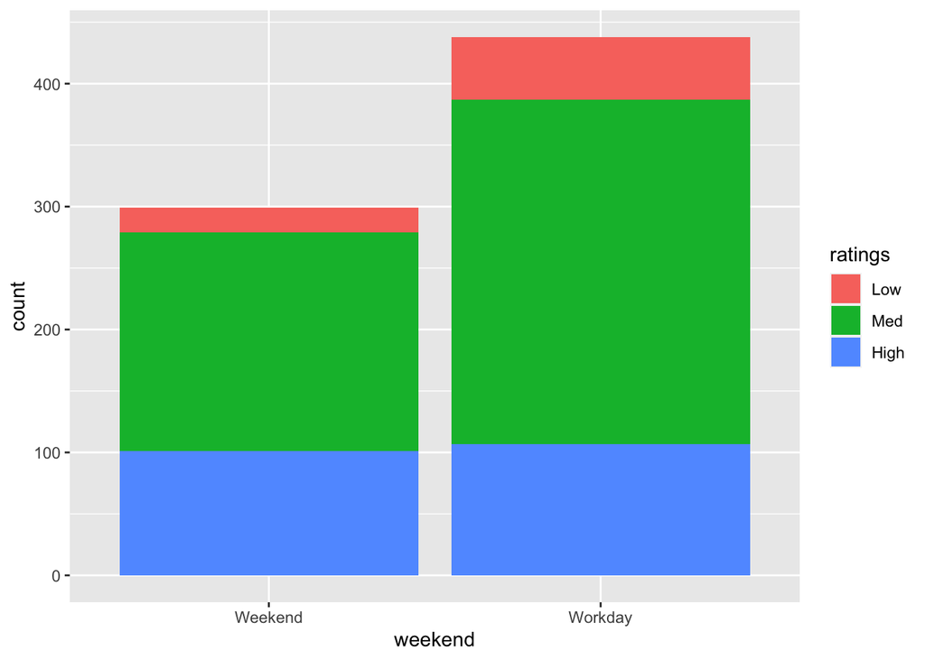

```r
ggplot(mateys_movies, aes(x = weekend)) + geom_bar(aes(fill = ratings))
```

2. (5pts) Use your graph from Part A to discuss the marginal distribution of `weekend` and the marginal distribution for `ratings`.

*By looking at the height of the bars, we can assess the marginal distribution of `weekend` - in particular, we can see that Matey rated more films on weekdays than on weekends. Meanwhile, by looking at the total area of each color, we can assess the marginal distribution of `ratings` - we see that the most common rating was medium (because there is more green area than the other colors), followed by a high rating, and finally a low rating.*

3. (10pts) Now make a stacked bar chart that involves `movie_period` and `day_of_week` such that you think it’s easiest to describe the marginal distribution of `movie_period`. After you’ve made your graph, explain in 1-2 sentences why you made the choices you made - i.e., how the choices you made allow you to most easily describe the marginal distribution of `movie_period`. (For this part, there’s no need to actually describe the marginal distribution.)

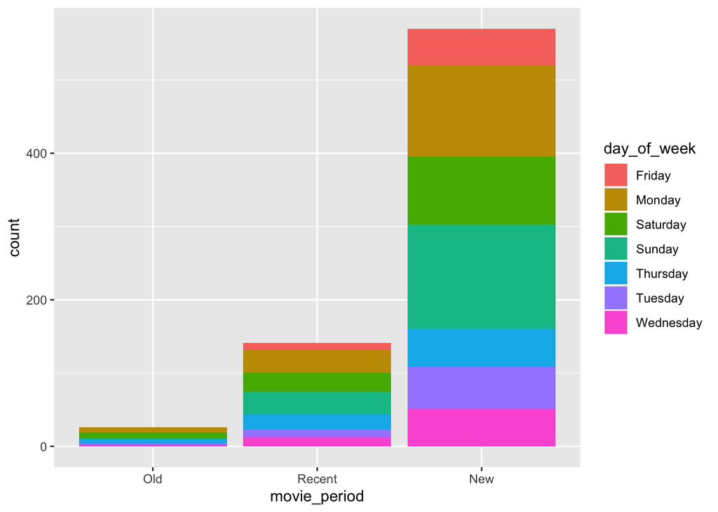

```r
ggplot(mateys_movies, aes(x = movie_period)) + geom_bar(aes(fill = day_of_week))
```

*From the previous exercise, we found that it was easier to assess the height of bars than the area of colors. Thus, we made the height of bars in this graph correspond to `movie_period`, such that it is easy to assess the marginal distribution of this variable. Note that it is actually quite difficult to assess the marginal distribution of `day_of_week` with this plot (because there are so many colors within each bar), but that is a sacrifice we are willing to make if our main priority is displaying the marginal distribution of `movie_period`.*

# Problem 3: Adding More Categories with Facetting (30 points)

In addition to visualizing a single categorical variable, we can also create the same visualization for different categories, thereby allowing for flexible multivariate graphics. This is known as “facetting,” where the data is grouped according to some categorical variable, and then we create the same graphic for each group. The resulting graphs are typically displayed in a grid, where each graph is a single “facet” of the full graphic.

This is a popular way to show how the features of the variable(s) being displayed in a particular graphic can change depending on some other variable (usually a categorical variable).

In Problem 2 you made a stacked bar plot for `weekend` and `ratings`. Alternatively, you could make two different bar plots for `ratings`, corresponding to the two different values for `weekend`. We’ll demonstrate how to do this using facetting.

1. (10pts) To make a bar plot of `ratings` facetted by `weekend`, follow these steps:
- First, make a bar plot of `ratings` the standard way (where `fill` is specified as a color within `geom_bar()`).
- Then, add `+ facet_grid(~ weekend)` to your existing line of code.

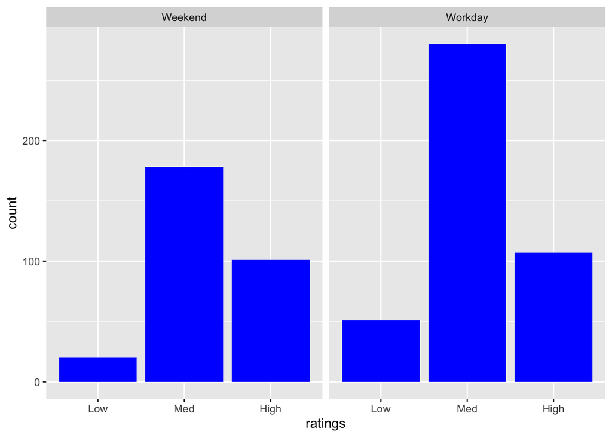

```r
ggplot(mateys_movies, aes(x = ratings)) + geom_bar(fill = "blue") + facet_grid(~ weekend)
```

You should see two bar plots graphed together, one for each value of `weekend`. After you’ve successfully made your plot, consider the following. When we have two categorical variables, there are four distributions we should consider: The marginal distribution of `ratings`, the marginal distribution of `weekend`, the conditional distribution of `ratings` given `weekend`, and the conditional distribution of `weekend` given `ratings`. (We’re focusing on marginal distributions this week - we’ll discuss conditional distributions next week.) Which plot makes it easier to see both marginal distributions: The facetted bar plot here, or the stacked bar plot in 2A? Explain your reasoning in 1-3 sentences.

*It seems somewhat easier to see the marginal distributions in the stacked bar plot in 2A than the facetted bar plot here. For the stacked bar plot, it is quite easy to see one marginal distribution by looking at just the heights of the bars - meanwhile, we could deduce the other marginal distribution by looking at the total area of each color. Meanwhile, for the facetted bar plot, in order to figure out the marginal distribution of `weekend`, we have to compare the total area of the left facet to the total area of the right facet; meanwhile, to figure out the marginal distribution of `ratings`, we have to compare the total height of the low, medium, and high bars. Thus, in the facetted plot, we have to compare total areas for both marginal distributions, which seems more difficult than having to compare total areas for only one marginal distribution.*

2. (10pts) You can also display marginal distributions by adding `margin = TRUE` within `facet_grid()`. So, copy-and-paste your code from Part A and then add `margin = TRUE` within `facet_grid()`. Your submission should display a third bar plot, labeled as “(all)”. This displays a marginal distribution - the marginal distribution of what?

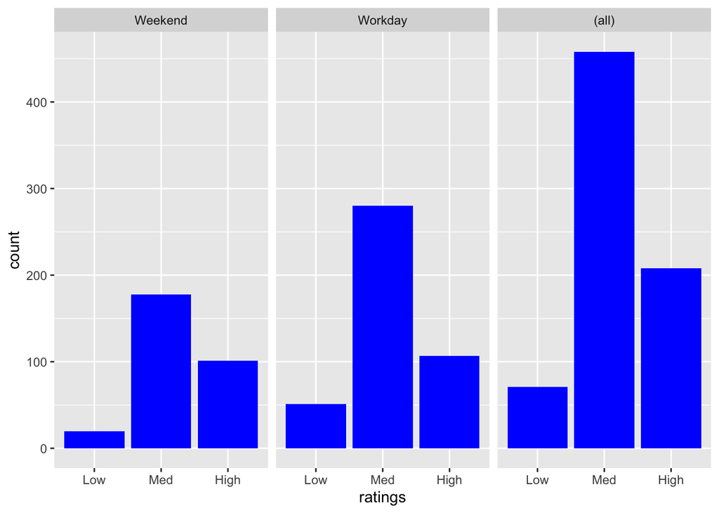

```r
ggplot(mateys_movies, aes(x = ratings)) + geom_bar(fill = "blue") + facet_grid(~ weekend, margin = TRUE)
```

*This displays the marginal distribution for `ratings`.*

3. (5pts) We can also facet stacked bar plots, thereby allowing for even more dimensions. Recreate the graph in Problem 2C, but this time, facet on `weekend` (don’t include `margin = TRUE`). For this part, all you have to do is make the desired graph. (You should end up with multiple facets of stacked bar plots, where each stacked bar plot involves `movie_period` and `day_of_week`.)

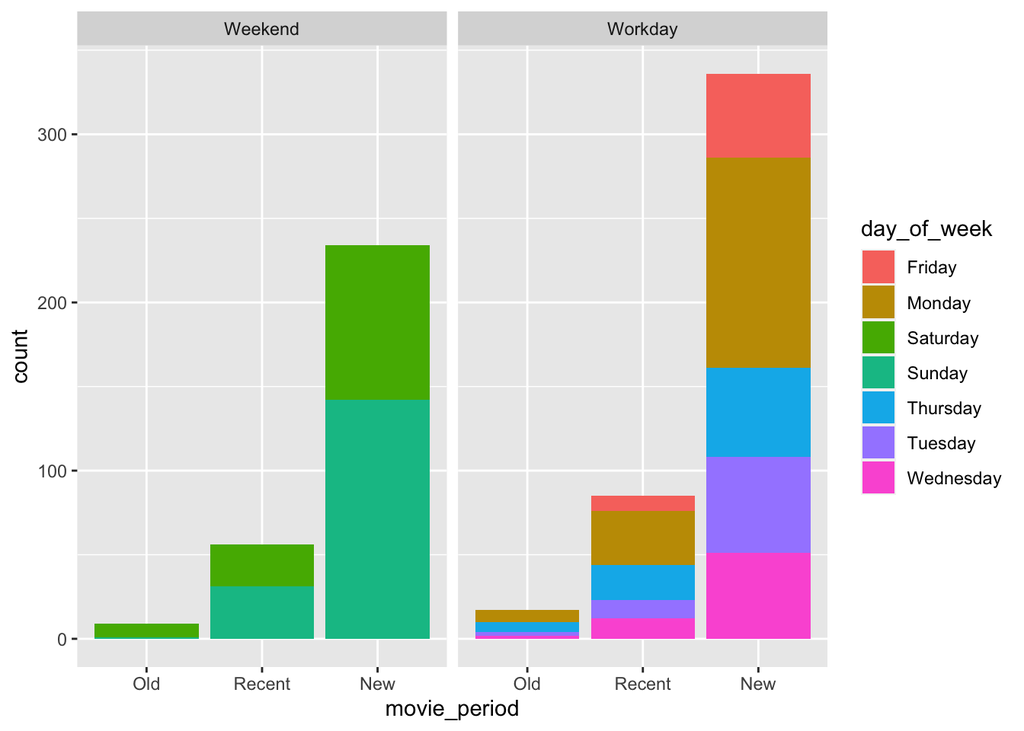

```r
ggplot(mateys_movies, aes(x = movie_period)) + geom_bar(aes(fill = day_of_week)) + facet_grid(~weekend)
```

4. (5pts) We can actually facet on multiple categorical variables at once. Recreate the graph in Problem 2C again, but this time facet by both `weekend` and `ratings` by adding `facet_grid(weekend ~ ratings)`. We won’t ask you to interpret this graph here, since there are four dimensions being plotted in this visual. The purpose of this problem is just to demonstrate that it’s pretty easy to make extensions to bar plots that allow for 3D and 4D graphs! (Of course, whether or not you’d actually *want* to display all four variables in a single graph is another story - we will discuss this throughout the semester.)

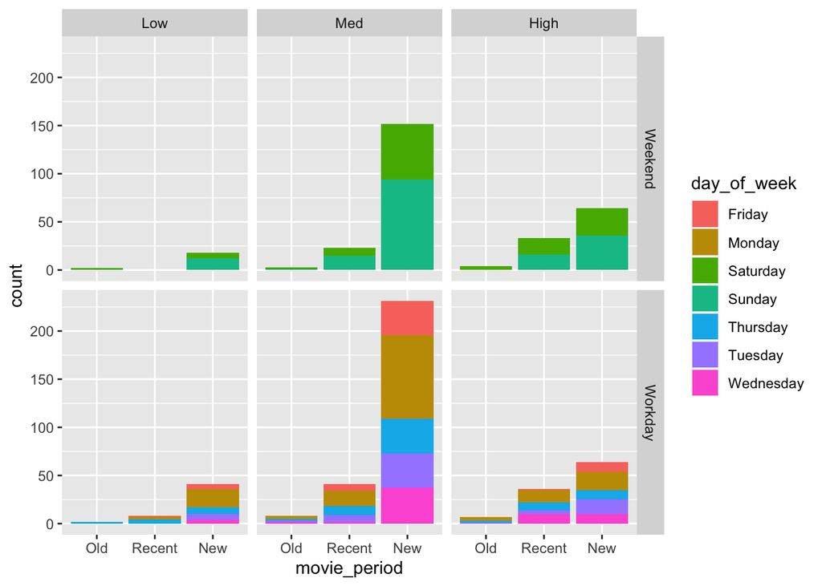

```r
ggplot(mateys_movies, aes(x = movie_period)) + geom_bar(aes(fill = day_of_week)) + facet_grid(weekend ~ ratings)
```